| 주차 | 일정 | 페이지 |
| --- | --- | --- |
| 1 | 1장-헬로 파이썬 | 0p ~ 45p |
| 2 | 2장-퍼셉트론 | 46p ~ 62p |
| 3 | 3장-신경망 | 63p ~ 105p |
| 4 | 4장-신경망 학습 | 106p ~ 146p |
| 5 | 5장-오차역전파법 | 147p ~ 187p (+ Appendix A, 292p ~ 299p) |
| 6 | 중간고사(전) |  |
| 7 | 중간고사 |  |
| 8 | 6장-학습 관련 기술들 | 188p ~ 226p |
| 9 | 7장-합성곱 신경망(CNN) | 227p ~ 259p |
| 10 | 딥러닝 | 261p ~ 308p |
| 11 | 1장-신경망 복습 | 0p ~ 74p (+ Appendix A, 389p ~ 394p) |
| 12 | 2장-자연어와 단어의 분산 표현 | 78p ~ 113p (+ Appendix B, 395p ~ 399p) |
| 13 | 기말고사(전) |  |
| 14 | 기말고사 |  |
| 15 | 3장-word2vec | 114p ~ 147p |
| 16 | 4장-word2vec 속도 개선 | 148p ~ 189p |
| 17 | 5장-순환신경망(RNN) | 190p ~ 235p |
| 18 | 6장-게이트가 추가된 RNN | 263p ~ 286p (+ Appendix C, 401p ~ 402p) |
| 19 | 7장-RNN을 사용한 문장 생성 | 287p ~ 333p |
| 20 | 8장-어텐션 | 334p ~ 387p |

# 22차

어텐션 모델 평가 + 마무리

*361p ~ 404p* (쪼갬)

```python
%run W21.ipynb
```

```
Q 10/15/94
T 1994-10-15
☒ 1978-08-11
---
Q thursday, november 13, 2008
T 2008-11-13
☒ 1978-08-11
---
Q Mar 25, 2003
T 2003-03-25
☒ 1978-08-11
---
Q Tuesday, November 22, 2016
T 2016-11-22
☒ 1978-08-11
---
Q Saturday, July 18, 1970
T 1970-07-18
☒ 1978-08-11
---
Q october 6, 1992
T 1992-10-06
☒ 1978-08-11
---
Q 8/23/08
T 2008-08-23
☒ 1978-08-11
---
Q 8/30/07
T 2007-08-30
☒ 1978-08-11
---
Q 10/28/13
T 2013-10-28
☒ 1978-08-11
---
Q sunday, november 6, 2016
T 2016-11-06
☒ 1978-08-11
---
```

[output cut: 355 more lines]

```
☑ 2008-08-23
---
Q 8/30/07
T 2007-08-30
☑ 2007-08-30
---
Q 10/28/13
T 2013-10-28
☑ 2013-10-28
---
Q sunday, november 6, 2016
T 2016-11-06
☑ 2016-11-06
---
정확도 100.000%
```

[figure not shown]

```python
import sys
sys.path.append('..')
import numpy as np
import matplotlib.pyplot as plt
from dataset import sequence
from common.optimizer import Adam
from common.trainer import Trainer
from common.util import eval_seq2seq
# from attention_seq2seq import AttentionSeq2seq
from common.seq2seq import Seq2seq
from common.peeky_seq2seq import PeekySeq2seq


# 데이터 읽기
(x_train, t_train), (x_test, t_test) = sequence.load_data('date.txt')
char_to_id, id_to_char = sequence.get_vocab()

# 입력 문장 반전
x_train, x_test = x_train[:, ::-1], x_test[:, ::-1]

# 하이퍼파라미터 설정
vocab_size = len(char_to_id)
wordvec_size = 16
hidden_size = 256
batch_size = 128
max_epoch = 10
max_grad = 5.0

model = AttentionSeq2seq(vocab_size, wordvec_size, hidden_size)
# model = Seq2seq(vocab_size, wordvec_size, hidden_size)
# model = PeekySeq2seq(vocab_size, wordvec_size, hidden_size)

optimizer = Adam()
trainer = Trainer(model, optimizer)

acc_list = []
for epoch in range(max_epoch):
    trainer.fit(x_train, t_train, max_epoch=1,
                batch_size=batch_size, max_grad=max_grad)

    correct_num = 0
    for i in range(len(x_test)):
        question, correct = x_test[[i]], t_test[[i]]
        verbose = i < 10
        correct_num += eval_seq2seq(model, question, correct,
                                    id_to_char, verbose, is_reverse=True)

    acc = float(correct_num) / len(x_test)
    acc_list.append(acc)
    print('정확도 %.3f%%' % (acc * 100))


model.save_params()

# 그래프 그리기
x = np.arange(len(acc_list))
plt.plot(x, acc_list, marker='o')
plt.xlabel('에폭')
plt.ylabel('정확도')
plt.ylim(-0.05, 1.05)
plt.show()
```

트레이닝 결과에서 나온 attention map을 살펴보면 흥미로운것들을 관찰 ㄱㄴ

[figure not shown]

세로가 결과이고 가로가 input, `friday`에는 집중 안함이 보이고,

월은 앞 2, 3번째 글자가 월을 표현하고,

연도는 그대로 전달됨을 볼 수 있다.

### 8.4 어텐션에 관한 남은 이야기

**양방향 LSTM**

기존의 LSTM구조는 사람이 읽는것처럼 왼쪽에서 오른쪽으로 글을 읽는데, 이 때문에 뒤에오는 단어와 앞의 단어의 연관성이랑 역으로 진행되는 문맥의 상황을 이해해서 hs를 만들기가 어렵다. 그래서 양방향으로 한다는 것:

[figure not shown]

기존 특징벡터의 절반씩 생성해서 append하는 방식임.

**Attention 계층의 (다양한) 사용 방법**

앞서 다룬 attention 계층 구조하는 방식 말고도 더 있다고 함. 테스트해보는 조건이나 기타 영향을 미칠 요인들이 있긴 하겠지만 여간 가능은 한거임, 구조 좀 바꾼다고 고장나진 않음.

**LSTM 심층화 & skip connection**

다른 신경망과 같이 LSTM도 쌓아서 쓸 수 있음:

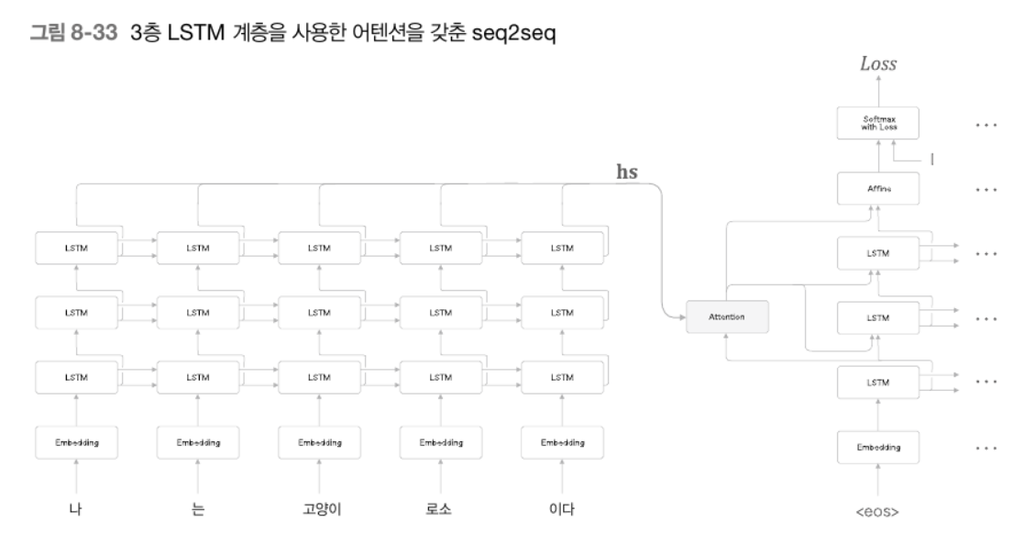

또 쌓으면 생기는 기울기 소실/폭팔 등의 문제를 방지하기 위해 전에 배운 skip-gram처럼 skip부분을 또 추가해줄 수 있음.

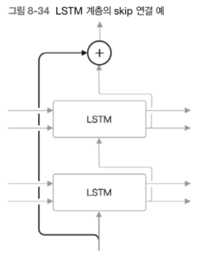

### 8.5 어텐션의 응용

1. 번역 (구글의 GMNT) Google Neural Machine Translation

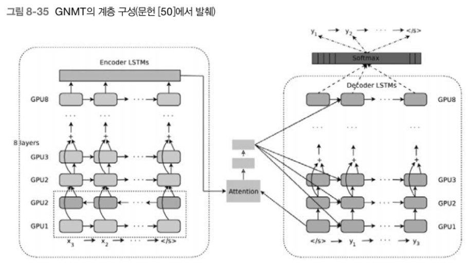

   앞서 언급한 다양한 개선 방안들을 다 모으고 그 외에도 추가적 개선을 추가한 모델
2. 트랜스포머 모델

   RNN은 구조상 일열로 연결된 시계열 부분이 있기에 GPU로 계산하기가 불가능/어렵고 이로 인해서 꽤나 느리다는 단점이 있음. 이를 해결하기 위해 이 시계열 부분을 완전히 없에버린 모델이 바로 트랜스포머!

   유명한 논문인 "Attention is all you need"의 의미가 바로 이것임. 그냥 시계열 없고 죄다 어텐션으로 훈련을 한다는 것.

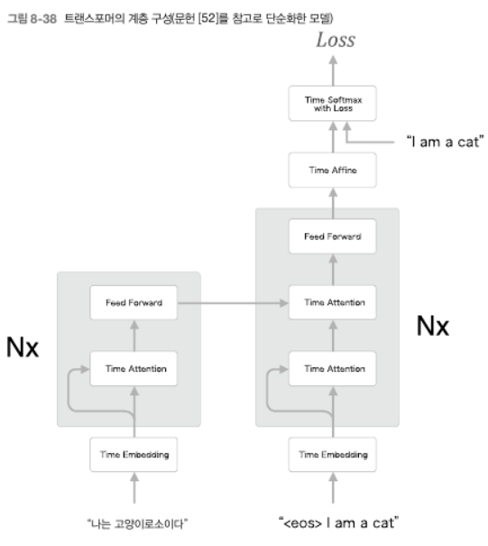

   그림에서 볼 수 있듯이, 어텐션을 쓰는데, 핵심이 셀프 어텐션. RNN에서 쓰는 단어별 어텐션이 아닌 문장 통째로 되먹임해서 어텐션을 생성. 문맥 찾는데 큰 역할을 준다고 함...

   핵심 장점은 성능임, 시계열을 없에고 encode/decode다 가능하니, 전 단계 계산 기다릴 필요 없이 바로 GPU로 병렬 계산 댸리면 됨. 그래서 결론적으로 GMNT보다 훈련시간 줄이고 그 시간으로 더 많은 데이터를 훈련할 수 있다.
3. 뉴럴 튜링 머신 (NMT)

   기존의 instruction set으로 작동하는 컴퓨터와 달리, NMT는 메모리 상에서 데이터의 이동, 계산등을 학습을 해서 수행한다는 개념이다. 덧셈이나 루프 돌리면 메모리에서 shift연산같은걸 진행하는데, NMT는 데이터를 적는 동시에 이러한 정보응 encode하고 읽는 컨트롤러가 decode할 때 shift -> increment같은걸 한다는 말이다. 정보처리도 시계열 순서라고 볼 수 있으니 이걸 다 훈련시켜서 메모리를 읽고 쓰기만 하면서 컴퓨터의 행동을 모방할 수 있다는 점에서 착안!